# AP-4209 ESIEE-Paris: 2023 -2024

Projet final : Classification bayésienne et Analyse Factorielle Discriminante

Adrien LINDEBERG – Théo LINDQVIST – Rémi Labou – Théo Labat  
ESIEE Paris - DSIA

Introduction : Lors de ce projet, on va mettre en place un modèle qui permetta de détecter si un texte est généré par une IA ou non. On mettra en place une classification bayésienne avancée avec analyse discriminante sur un jeu de données de textes afin de les catégoriser en deux catégories: texte générées par IA, texte généré par un humain. On récupère notre dataset sur un concours kaggle: ([IA Dataset](https://www.kaggle.com/competitions/llm-detect-ai-generated-text)). Ce dataset possède quatre colonnes. - id: id du texte - prompt_id: id du prompt d’où provient le texte - text : le texte où l’on veut savoir si il vient d’une IA ou d’un humain - generated : cette colonne nous imforme si ce texte est généré par IA ou pas

Objectif principal : Développez un système de classification sophistiqué qui utilise des méthodes bayésiennes améliorées par des caractéristiques extraites par l’analyse factorielle discriminante pour faire la distinction entre le texte généré par l’homme et le texte généré par l’IA.

## 1. Chargement et exploration des données :

Nous allons explorer notre dataset afin de mieux comprendre la manière dont il est construit et mieux préparer le prétraitement des données et ainsi permettre une meilleure analyse factorielle discriminante.

On n’oublie pas d’abord d’effacer toutes les variables en mémoire:

```r
rm(list = ls())

gc()
```

```
##          used (Mb) gc trigger (Mb) max used (Mb)
## Ncells 524707 28.1    1168971 62.5   660382 35.3
## Vcells 963357  7.4    8388608 64.0  1770407 13.6
```

On charge les packages nécessaires:

```r
library(ggplot2)
library(lattice)
library(kableExtra)
library(caret)
library(tidyverse)
library(stringr)
library(text)
library(tidytext)
library(textstem)
library(koRpus)
library(tm)
library(reshape2)
library(RColorBrewer)
library(wordcloud)
library(syuzhet)
library(lubridate)
library(scales)
library(MASS)
library(naivebayes)
library(e1071)
library(SnowballC)
```

#### 1.1 Visualisation des données :

Dans un premier temps, on charge le dataset du concours.

```r
#on récupère le dataset train_essays
df <- read.csv("dataset/llm-detect-ai-generated-text/llm-detect-ai-generated-text/train_essays.csv")

cat("Dimensions de df : ", dim(df), "\n")
```

```
## Dimensions de df :  1378 4
```

```r
df %>%
  head(1) %>%
  kbl() %>%
  kable_styling(bootstrap_options = "striped", full_width = FALSE,
                position = "center")
```

| id | prompt_id | text | generated |
| --- | --- | --- | --- |
| 0059830c | 0 | Cars. Cars have been around since they became famous in the 1900s, when Henry Ford created and built the first ModelT. Cars have played a major role in our every day lives since then. But now, people … | 0 |

Notre dataset possède quatre colonnes et 1378 échantillons. La colonne id correspond à l’id du texte. Nous avons aussi l’id du prompt. Dans notre dataset nous avons, pour l’instant de prompt disponible donc l’id du prompt prend la forme d’une valeur binaire. Nous avons évidemment la colonne contenant les textes dont on devra identifier si ils sont générés par IA. Et pour finir, la colonne generated qui est la colonne à prédire et qui est binaire: si le texte est écrit par un humain alors l’échantillon vaudra 0 sinon 1.

```r
str(df)
```

```
## 'data.frame':    1378 obs. of  4 variables:
##  $ id       : chr  "0059830c" "005db917" "008f63e3" "00940276" ...
##  $ prompt_id: int  0 0 0 0 0 1 1 0 1 1 ...
##  $ text     : chr  "Cars. Cars have been around since they became famous in the 1900s, when Henry Ford created and built the first "| __truncated__ "Transportation is a large necessity in most countries worldwide. With no doubt, cars, buses, and other means of"| __truncated__ "\"America's love af…
##  $ generated: int  0 0 0 0 0 0 0 0 0 0 ...
```

La fonction str nous montre les premières lignes du dataset et le type de chaque colonne. Les colonne id et texte sont des strings tandis que prompt_id et generated sont des int.

On vérifie qu’il n’y a pas de valeurs manquantes ou vides dans notre dataset:

```r
#Nombre de valeurs de valeurs manquantes et vides dans df
cat("Nombre de valeurs de valeurs manquantes dans df : ", sum(is.na(df)), "\n")
```

```
## Nombre de valeurs de valeurs manquantes dans df :  0
```

```r
cat("Nombre de valeurs de valeurs vides dans df : ", sum(sapply(df, function(col) sum(col == "" | sapply(col, function(x) length(x) == 0)))), "\n")
```

```
## Nombre de valeurs de valeurs vides dans df :  0
```

Il n’y a aucune valeurs manquantes ni vides dans notre dataset.

On regarde si certain id reviennent plusieurs fois:

```r
#Nombre de valeurs de la colonne id
cat("Nombre de valeurs de la colonne id : ", length(unique(df$id)), "\n")
```

```
## Nombre de valeurs de la colonne id :  1378
```

On remarque qu’il y a autand d’id que de ligne donc on va supprimer cette ligne car elle est inutile.

```r
#suppression de la colonne id
df <- subset(df, select = -id)
cat("Nouvelles dimensions de df : ", dim(df), "\n")
```

```
## Nouvelles dimensions de df :  1378 3
```

Maintenant, notre dataset possède plus que trois colonnes et 1378 lignes.

On regarde la distribution de la colonne prompt_id pour savoir si un prompt est plus utilisée que l’autre.

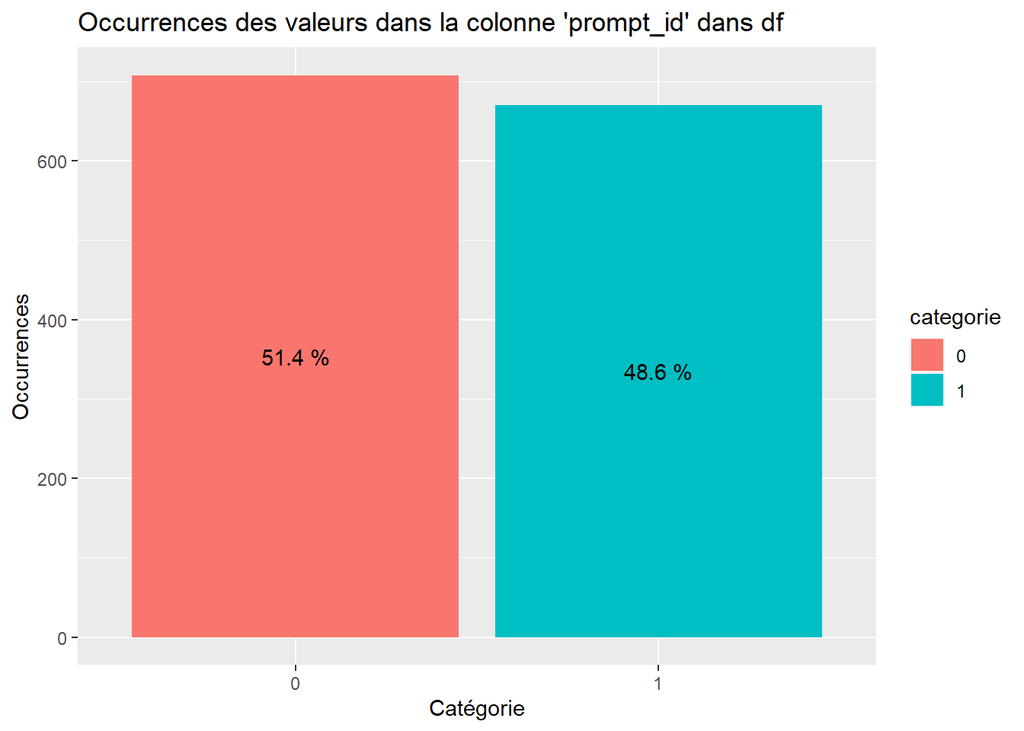

```r
occurrences <- table(df$prompt_id)
occurrences_df <- as.data.frame(occurrences)
names(occurrences_df) <- c("categorie", "occurrences")

occurrences_df %>%
  ggplot(aes(x = categorie, y = occurrences, fill = categorie)) +
  geom_bar(stat = "identity") +
  geom_text(aes(label = paste(round(occurrences / nrow(df), 3) * 100, "%")),
            position = position_stack(vjust = 0.5)) +
  labs(title = "Occurrences des valeurs dans la colonne 'prompt_id' dans df",
       x = "Catégorie",
       y = "Occurrences")
```

Le premier prompt (0) revient 51,4% des fois tandis que le deuxième (1) revient donc 48,6% des fois. C’est le même ordre de grandeur et on peut donc partir du principe qu’il y a autant de chance de tomber sur l’un des deux.

On vérifie que genrated est binaire:

```r
#Nombre de valeurs de la colonne generated
cat("Nombre de valeurs de la colonne generated : ", length(unique(df$generated)), "\n")
```

```
## Nombre de valeurs de la colonne generated :  2
```

La valeur que l’on doit prédire est bien binaire.

Maintenant, on regarde la distribution de la colonne generated.

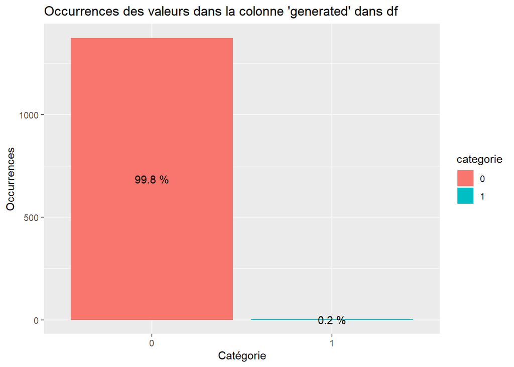

```r
occurrences <- table(df$generated)
occurrences_df <- as.data.frame(occurrences)
names(occurrences_df) <- c("categorie", "occurrences")

occurrences_df %>%
  ggplot(aes(x = categorie, y = occurrences, fill = categorie)) +
  geom_bar(stat = "identity") +
  geom_text(aes(label = paste(round(occurrences / nrow(df), 3) * 100, "%")),
            position = position_stack(vjust = 0.5)) +
  labs(title = "Occurrences des valeurs dans la colonne 'generated' dans df",
       x = "Catégorie",
       y = "Occurrences")
```

On remarque qu’il n’y a presque aucun texte généré par IA dans notre dataset. Il représente à peine 0.2% de tout les échantillons. Cette distribution de la colonne generated ne nous permet pas de faire un modèle robuste et fiable pour reconnaître si un texte est généré par IA ou par un humain.

On doit donc trouver un solution pour rendre notre dataset beaucoup plus complet. On a ainsi décidée d’ajouter des données d’autres datasets kaggle: https://www.kaggle.com/datasets/thedrcat/daigt-proper-train-dataset/ On trouve avec ce lien quatre datasets différents ressemblant beaucoup à notre ancien dataset. On retrouve un texte, le nom du prompt et une colonne qui nous dit dit si le texte est générée par IA.

L’ensemble de ces quatre datasets représente un trop grand nombre de lignes (plus de 100 000 lignes). On est donc obligée de le réduire. On a choisie comme stratégie de prendre 1500 lignes de chaque dataset où la moitié contient un texte écrit par un humain et l’autre moitié est générée par une IA.

On récupère le premier dataset et gardons que 1500 lignes:

```r
df1 <- read.csv("new_dataset/train_drcat_01.csv")[c("text", "source", "label")]

cat("Dimensions de df1 : ", dim(df1), "\n")
```

```
## Dimensions de df1 :  33259 3
```

```r
df1 %>%
  head(1) %>%
  kbl() %>%
  kable_styling(bootstrap_options = "striped", full_width = FALSE,
                position = "center")
```

| text | source | label |
| --- | --- | --- |
| There are alot reasons to keep our the despised method of choosing the President. The First reason is because Certainty of Outcome, in the text its states that “The reason is that the winning candidat… | persuade_corpus | 0 |

```r
zeros <- subset(df1, label == 0)
ones <- subset(df1, label == 1)

n <- 750
sampled_zeros <- zeros[sample(nrow(zeros), n), ]
sampled_ones <- ones[sample(nrow(ones), n), ]

sample_df1 <- rbind(sampled_zeros, sampled_ones)

cat("Nouvelles dimensions de df1 : ", dim(sample_df1), "\n")
```

```
## Nouvelles dimensions de df1 :  1500 3
```

On passe ainsi d’un dataset de plus de 33000 lignes à un dataset de seulement 1500 lignes.

On récupère le deuxième dataset:

```r
df2 <- read.csv("new_dataset/train_drcat_02.csv")[c("text", "source", "label")]

cat("Dimensions de df2 : ", dim(df2), "\n")
```

```
## Dimensions de df2 :  39785 3
```

```r
df2 %>%
  head(1) %>%
  kbl() %>%
  kable_styling(bootstrap_options = "striped", full_width = FALSE,
                position = "center")
```

| text | source | label |
| --- | --- | --- |
| Okay, here is my essay: Working or doing things individually can have a lot of benefits. When people work or do things by themselves, they can develop important skills that help them succeed in life. … | llama2_chat | 1 |

```r
zeros <- subset(df2, label == 0)
ones <- subset(df2, label == 1)

n <- 750
sampled_zeros <- zeros[sample(nrow(zeros), n), ]
sampled_ones <- ones[sample(nrow(ones), n), ]

sample_df2 <- rbind(sampled_zeros, sampled_ones)

cat("Nouvelles dimensions de df2 : ", dim(sample_df2), "\n")
```

```
## Nouvelles dimensions de df2 :  1500 3
```

On passe ainsi d’un dataset d’environ 40000 lignes à un dataset de seulement 1500 lignes.

On récupère le troisième dataset:

```r
df3 <- read.csv("new_dataset/train_drcat_03.csv")[c("text", "source", "label")]

cat("Dimensions de df3 : ", dim(df3), "\n")
```

```
## Dimensions de df3 :  42206 3
```

```r
df3 %>%
  head(1) %>%
  kbl() %>%
  kable_styling(bootstrap_options = "striped", full_width = FALSE,
                position = "center")
```

| text | source | label |
| --- | --- | --- |
| People can learn without making mistakes. People should seek guidance from experts and authorities about life’s important. People should not make their own decision. First, they would learn in a bette… | original_moth | 0 |

```r
zeros <- subset(df3, label == 0)
ones <- subset(df3, label == 1)

n <- 750
sampled_zeros <- zeros[sample(nrow(zeros), n), ]
sampled_ones <- ones[sample(nrow(ones), n), ]

sample_df3 <- rbind(sampled_zeros, sampled_ones)

cat("Nouvelles dimensions de df3 : ", dim(sample_df3), "\n")
```

```
## Nouvelles dimensions de df3 :  1500 3
```

On passe ainsi d’un dataset d’environ 42000 lignes à un dataset de seulement 1500 lignes.

On récupère le dernier dataset:

```r
df4 <- read.csv("new_dataset/train_drcat_04.csv")[c("text", "source", "label")]

cat("Dimensions de df4 : ", dim(df4), "\n")
```

```
## Dimensions de df4 :  44206 3
```

```r
df4 %>%
  head(1) %>%
  kbl() %>%
  kable_styling(bootstrap_options = "striped", full_width = FALSE,
                position = "center")
```

| text | source | label |
| --- | --- | --- |
| In recent years, technology has had a profound impact on our daily lives and the world around us. From staying connected with loved ones to ordering food online through an app, technology has made our… | mistral7binstruct_v2 | 1 |

```r
zeros <- subset(df4, label == 0)
ones <- subset(df4, label == 1)

n <- 750
sampled_zeros <- zeros[sample(nrow(zeros), n), ]
sampled_ones <- ones[sample(nrow(ones), n), ]

sample_df4 <- rbind(sampled_zeros, sampled_ones)

cat("Nouvelles dimensions de df4 : ", dim(sample_df4), "\n")
```

```
## Nouvelles dimensions de df4 :  1500 3
```

On passe ainsi d’un dataset d’environ 44000 lignes à un dataset de seulement 1500 lignes.

Maintenant qu’on a récupéré 1500 échantillons de chaque dataset, on va fusionner pour avoir un dataset de 6000 lignes au total:

```r
df <- rbind(sample_df1, sample_df2, sample_df3, sample_df4)

cat("Dimensions de df : ", dim(df), "\n")
```

```
## Dimensions de df :  6000 3
```

```r
cat("Nombre de valeurs de valeurs manquantes dans df : ", sum(is.na(df)), "\n")
```

```
## Nombre de valeurs de valeurs manquantes dans df :  0
```

```r
cat("Nombre de valeurs de valeurs vides dans df : ", sum(trimws(df$text) == ""))
```

```
## Nombre de valeurs de valeurs vides dans df :  0
```

On a maintenant un dataset de 6000 lignes avec toujours aucune valeurs manquantes et vides. Le nom de nos colonnes ont cependant changé. Maintenant, on a 3 colonnes avec le colonne text qui correspond toujours au texte, la colonne source qui est la source du texte et la colonne label qui est la colonne à prédire.

On vérifie bien que la distribution de la colonne label est viable:

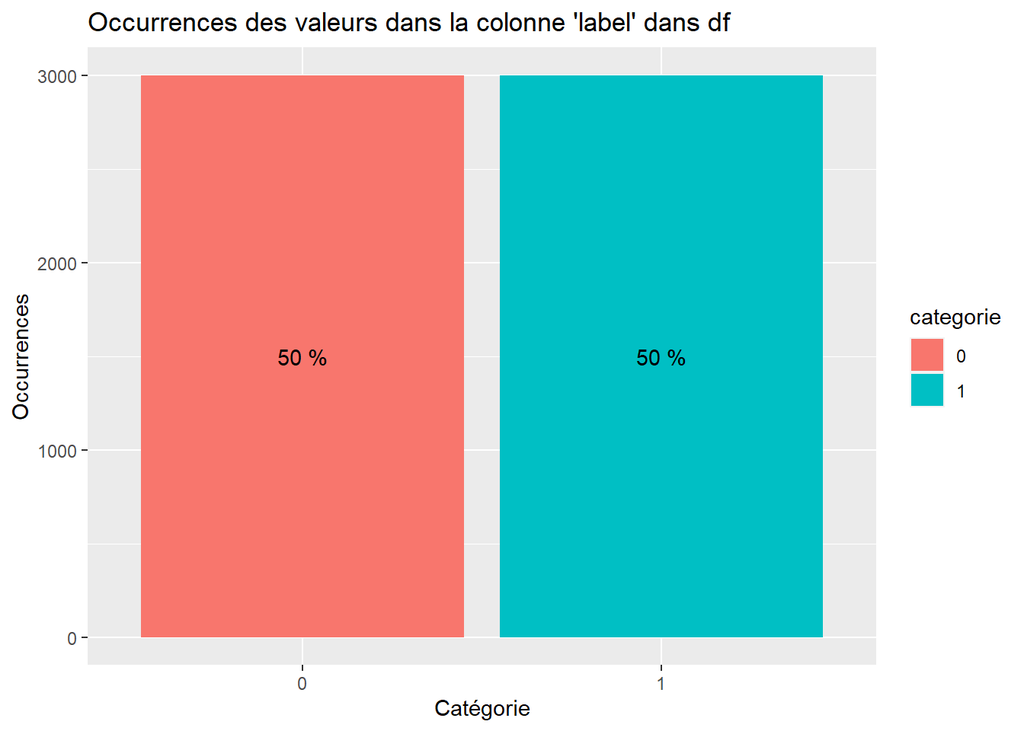

```r
occurrences <- table(df$label)
occurrences_df <- as.data.frame(occurrences)
names(occurrences_df) <- c("categorie", "occurrences")

occurrences_df %>%
  ggplot(aes(x = categorie, y = occurrences, fill = categorie)) +
  geom_bar(stat = "identity") +
  geom_text(aes(label = paste(round(occurrences / nrow(df), 3) * 100, "%")),
            position = position_stack(vjust = 0.5)) +
  labs(title = "Occurrences des valeurs dans la colonne 'label' dans df",
       x = "Catégorie",
       y = "Occurrences")
```

Comme prévu, il y a 50% de texte généré par IA et 50% de texte écrit par un humain.

On veut voir avant le prétraitement de nos données quelles sont les mots qui reviennent le plus dans la colonne text:

```r
corpus <- Corpus(VectorSource(df$text))
corpus <- tm_map(corpus, content_transformer(tolower))
corpus <- tm_map(corpus, removePunctuation)
```

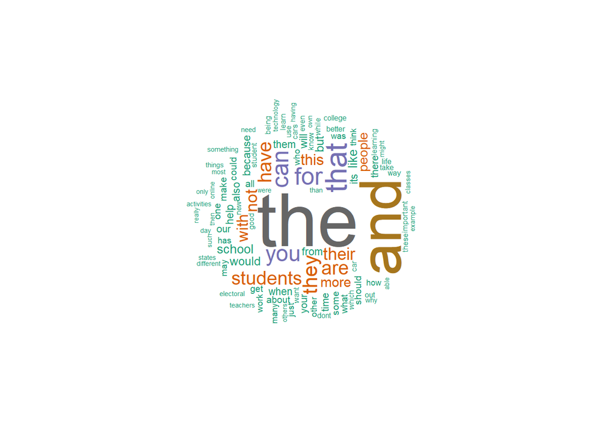

```r
tdm <- as.matrix(TermDocumentMatrix(corpus))

w <- sort(rowSums(tdm), decreasing = TRUE)
set.seed(222)
wordcloud(words = names(w),
          freq = w,
          max.words = 100,
          random.order = FALSE,
          min.freq = 5,
          colors = brewer.pal(8, "Dark2"),
          scale = c(5, 0.3),
          rot.per = 0.7)
```

Evidemment, les mots qui reviennent le plus souvent pour l’instant ne sont pas des mots intéressants tel que the et and. On va donc dans la prochaine partie créer une colonne clean_text où l’on va nettoyer nos textes(supprimer mots vides, mots courts) et faire un stemming et une lemmatization.

#### 1.2 Prétraitement des données :

Pour nettoyer nos textes, on écrit une fonction qui va supprimer les motes vides et les mots de moins de trois lettres puis appliquer un stemming et une lemmatization à chaque mots:

```r
clean_text <- function(text) {
  text <- tolower(text)

  #supprime mots courts
  text <- str_split(text, "\\s+")
  text <- unlist(text)
  text <- text[str_length(text) > 3]

  #supprime stopwords
  stopwords <- stopwords("en")
  stopwords_pattern <- paste0("\\b", paste(stopwords,
                                           collapse = "\\b|\\b"), "\\b")
  text <- str_replace_all(text, stopwords_pattern, "")

  #stemming et lemmatization
  text <- wordStem(text, language = "english")
  text <- lemmatize_words(text)

  preprocessed_text <- str_trim(paste(text, collapse = " "))

  return(preprocessed_text)
}
```

On applique cette fonction sur notre dataset:

```r
#applique fonction sur les colonnes nécessaires
df <- df %>%
  mutate(clean_text = lapply(text, clean_text))
```

```r
head(df, 1)
```

```
##                                                                                                                                                                                                                                                                                                          …
## 20526 Dear Principal,\n\nMy name is STUDENT_NAME and I would like to explain to you why I think it would be a good idea to make only people with B averages be allowed to play sports or activities.\n\nMany students in our school have a C average. Which means that a lot of people in the school coul…
##                source label
## 20526 persuade_corpus     0
##                                                                                                                                                                                                                                                                                                          …
## 20526 dear principal, name student_nam  like explain think  good idea make  peopl  averag allow play sport activities. mani student school  average.  mean  peopl school  play sport activities. understand  reason  like student  averag particip strong agree. first, opinion,   homework time,  also  …
```

On voit bien que le texte de la première ligne dans la colonne clean_text a été bien modifié par rapport au text de la colonne text.

Pour mieux se rendre compte de la différence entre les textes avant et après nettoyange, on regarde de nouveau quelles sont les mots qui reviennent le plus dans les textes nettoyés.

```r
corpus <- Corpus(VectorSource(df$clean_text))
corpus <- tm_map(corpus, content_transformer(tolower))
corpus <- tm_map(corpus, removePunctuation)
```

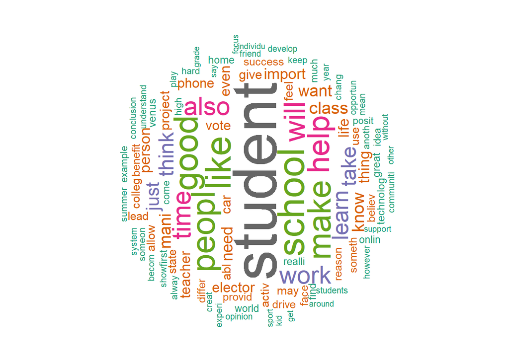

```r
tdm <- as.matrix(TermDocumentMatrix(corpus))

w <- sort(rowSums(tdm), decreasing = TRUE)
set.seed(222)
wordcloud(words = names(w),
          freq = w,
          max.words = 100,
          random.order = FALSE,
          min.freq = 5,
          colors = brewer.pal(8, "Dark2"),
          scale = c(5, 0.3),
          rot.per = 0.7)
```

On voit une réelle différence entre les graphes avant et après et nettoyage. Maintenant, les mots qui reviennent le plus souvent sont student, peopl ou encore school ce qui est plus intéressant que the et and.

```r
#transforme en facteur les colonnes generated et prompt_id
df$source <- as.numeric(factor(df$source, levels = unique(df$source))) - 1
df$label <- factor(df$label, levels = unique(df$label), labels = c("human", "IA"))
```

## 2. Extraction de caractéristiques (Feature Extraction) :

Dans cette partie, on va extraire les caractéristiques de nos textes pour les convertir dans un format adapté. En effet, on ne peut pas passer notre dataset sous cette forme dans un quelconque modèle. Pour cela, on va utilisé dans un premier temps une TF-IDF puis on va claculer certaines caractéristiques de nos textes comme leur perplexité ou la variabilité de leurs phrases.

#### 2.1 TF-IDF :

On applique une TF-IDF à nos textes nettoyés c’est à dire une vectorisation du texte en utilisant la méthode de la fréquence des termes et de la fréquence inverse du document. Pour cela, on transforme d’abord notre colonne en corpus puis on utilise la méthode DocumentTermMatrix qui calcule la TF-IDF du corpus.

```r
corpus <- Corpus(VectorSource(df$clean_text))
corpus <- tm_map(corpus, content_transformer(tolower))
corpus <- tm_map(corpus, removePunctuation)
dtm <- DocumentTermMatrix(corpus)
# on supprime les colonnes où le mot est présent dans moins de 0.25% des phrases
empty_cols <- colSums(as.matrix(dtm) != 0) <= 20
dtm <- dtm[, !empty_cols]
tfidf <- weightTfIdf(dtm)
tfidf <- as.matrix(tfidf)
tfidf_df <- as.data.frame(tfidf)
```

```r
cat("Dimensions de le tf-idf : ", dim(tfidf_df), "\n")
```

```
## Dimensions de le tf-idf :  6000 3117
```

```r
tfidf_df[, 1:20] %>%
  head() %>%
  kbl() %>%
  kable_styling(bootstrap_options = "striped", full_width = FALSE,
                position = "center")
```

| activ | activities | activity | addition | agree | allow | also | assignment | averag | average | believ | child | come | dear | effort | encourag | even | excus | explain | extra |
| --- | --- | --- | --- | --- | --- | --- | --- | --- | --- | --- | --- | --- | --- | --- | --- | --- | --- | --- | --- |
| 0.0214591 | 0.0569828 | 0.0384788 | 0.0413542 | 0.0591606 | 0.0166087 | 0.0052253 | 0.0508961 | 0.0928114 | 0.0910141 | 0.0159321 | 0.0617680 | 0.0155379 | 0.0257015 | 0.0302645 | 0.0296278 | 0.0228649 | 0.0668704 | 0.0356392 | 0.0665003 |
| 0.0000000 | 0.0000000 | 0.0000000 | 0.0000000 | 0.0000000 | 0.0000000 | 0.0145346 | 0.0000000 | 0.0000000 | 0.0000000 | 0.0000000 | 0.0000000 | 0.0000000 | 0.0000000 | 0.0000000 | 0.0000000 | 0.0000000 | 0.0000000 | 0.0000000 | 0.0000000 |
| 0.0000000 | 0.0190467 | 0.0000000 | 0.0000000 | 0.0000000 | 0.0222061 | 0.0000000 | 0.0000000 | 0.0000000 | 0.0000000 | 0.0000000 | 0.0619387 | 0.0103872 | 0.0000000 | 0.0000000 | 0.0000000 | 0.0000000 | 0.0000000 | 0.0000000 | 0.0000000 |
| 0.0000000 | 0.0000000 | 0.0000000 | 0.0000000 | 0.0000000 | 0.0000000 | 0.0049012 | 0.0000000 | 0.0000000 | 0.0000000 | 0.0000000 | 0.0000000 | 0.0291487 | 0.0000000 | 0.0000000 | 0.0000000 | 0.0107235 | 0.0000000 | 0.0000000 | 0.0000000 |
| 0.0000000 | 0.0000000 | 0.0000000 | 0.0000000 | 0.0000000 | 0.0000000 | 0.0000000 | 0.0000000 | 0.0000000 | 0.0000000 | 0.0000000 | 0.0000000 | 0.0000000 | 0.0000000 | 0.0000000 | 0.0000000 | 0.0000000 | 0.0000000 | 0.0000000 | 0.0000000 |
| 0.0000000 | 0.0000000 | 0.0000000 | 0.0000000 | 0.0000000 | 0.0000000 | 0.0160471 | 0.0000000 | 0.0000000 | 0.0000000 | 0.0000000 | 0.0000000 | 0.0095436 | 0.0000000 | 0.0000000 | 0.0000000 | 0.0351099 | 0.0000000 | 0.0000000 | 0.0000000 |

On peut voir que chaque colonne correspond à un mot différents.

#### 2.2 Caractéristiques linguistiques :

Après avoir calculé la TF-IDF de nos textes nettoyés, on va maintenant calculer plusieurs caractéristiques de nos textes de départ.

Pour commencer on calcule la perplexité de chaque texte. Pour cela, on crée une fonction perplexity.

Celle- ci prend en paramètre un texte et calcule sa diversité lexicale. Pour cela, elle utilise la fonction tokenize_words du package tokenizers pour diviser le texte en mots et retourner une liste de tokens. Puis, elle compte le nombre de tokens différents dans le texte et le divise par le nombre total de tokens et nous renvoie cette valeur.

```r
library(tokenizers)
perplexity <- function(text) {

  tokens <- unlist(tokenize_words(text))
  lexical_diversity <- length(unique(tokens)) / length(tokens)

  return(lexical_diversity)
}

perplexity_text <- sapply(df$text, perplexity)

print(paste("perplexité du texte:", head(perplexity_text)))
```

```
## [1] "perplexité du texte: 0.458471760797342"
## [2] "perplexité du texte: 0.53"
## [3] "perplexité du texte: 0.413978494623656"
## [4] "perplexité du texte: 0.496"
## [5] "perplexité du texte: 0.598930481283422"
## [6] "perplexité du texte: 0.345724907063197"
```

```r
cat("Nombre de valeurs de valeurs manquantes dans df : ", sum(is.na(perplexity_text)))
```

```
## Nombre de valeurs de valeurs manquantes dans df :  0
```

On voit que la perplexité des six premiers textes varient entre 0.25 et 0.65 ce qui laisse penser qu’il peut y avoir des différences entre les textes généré par IA et les textes écrit par un humain. Cette colonne pourrait donc être intéressante.

On calcule aussi la variabilité des phrases de chaque texte. Pour cela, on crée une fonction variabilite_longueur. Cette fonction prend aussi en paramètre un texte et calcule la variabilité des longueurs des phrases de ce texte. Pour cela, elle utilise la fonction tokenize_sentences pour diviser le texte en phrases et stocke ces phrases dans une variable phrases. Ensuite, elle calcule la longueur de chaque phrase à l’aide de la fonction nchar (calcule le nombre de caractères). Si le texte ne contient qu’une seule phrase, elle retourne simplement la longueur de cette phrase (permet d’éviter valeurs manquantes avec la fonction sd). Sinon, elle calcule l’écart-type des longueurs de phrases à l’aide de la fonction sd et retourne cette valeur.

```r
variabilite_longueur <- function(texte) {

  phrases <- unlist(tokenize_sentences(texte))
  longueur_phrases <- nchar(phrases)

  if (length(longueur_phrases) == 1) {
    return(longueur_phrases)
  }

  variabilite_longueur <- sd(longueur_phrases)

  return(variabilite_longueur)
}

variabilite_phrases <- sapply(df$text, variabilite_longueur)

print(paste("Variabilité de la longueur du text:", head(variabilite_phrases)))
```

```
## [1] "Variabilité de la longueur du text: 54.4589841291678"
## [2] "Variabilité de la longueur du text: 75.4446214722488"
## [3] "Variabilité de la longueur du text: 25.8560930808797"
## [4] "Variabilité de la longueur du text: 203.206716663032"
## [5] "Variabilité de la longueur du text: 56.9630205860409"
## [6] "Variabilité de la longueur du text: 31.6429251594046"
```

```r
cat("Nombre de valeurs de valeurs manquantes dans df : ", sum(is.na(variabilite_phrases)))
```

```
## Nombre de valeurs de valeurs manquantes dans df :  0
```

On voit que la variabilité des phrases des six premiers textes varient ce qui laisse penser qu’il peut y avoir des différences entre les textes généré par IA et les textes écrit par un humain. Cette colonne pourrait donc être intéressante.

Pour finir, on calcule le score de lisibilité de chaque texte. Pour cela, on crée une fonction lisibilite_texte. Cette fonction calcule l’indice de lisibilité Flesch-Kincaid d’un texte. Pour cela, elle divise le texte en mots à l’aide de la fonction strsplit. Elle compte le nombre total de mots dans le texte. Elle compte le nombre total de phrases dans le texte en utilisant la fonction tokenize_sentences. Elle calcule le nombre total de syllabes dans le texte. On part du principe que le nombre de voyelles dans un mot correspond au nombre de syllabes de ce mot. Ensuite, elle calcule l’indice de lisibilité Flesch-Kincaid avec la formule: 206.835 - 1.015 * (nb_mots / nb_phrases) - 84.6 * (nb_syllabes / nb_mots) Cette formule est très utilisé pour calculer la lisibilté d’un texte.

```r
lisibilite_texte <- function(texte) {

  mots <- unlist(strsplit(texte, "\\s+"))
  nb_mots <- length(mots)
  nb_phrases <- length(unlist(tokenize_sentences(texte)))
  nb_syllabes <- sum(sapply(mots, function(mot) sum(grepl("[aeiouy]", tolower(mot)))))

  #calcule l'indice de lisibilité Flesch-Kincaid pour le texte entier
  score <- 206.835 - 1.015 * (nb_mots / nb_phrases) - 84.6 * (nb_syllabes / nb_mots)

  return(score)
}

score_lisibilite <- sapply(df$text, lisibilite_texte)
print(paste("Score de lisibilité moyen:", head(score_lisibilite)))
```

```
## [1] "Score de lisibilité moyen: 102.991585825028"
## [2] "Score de lisibilité moyen: 103.780454545455"
## [3] "Score de lisibilité moyen: 105.81847826087"
## [4] "Score de lisibilité moyen: 92.77225"
## [5] "Score de lisibilité moyen: 100.078125"
## [6] "Score de lisibilité moyen: 104.235666666667"
```

```r
cat("Nombre de valeurs de valeurs manquantes dans df : ", sum(is.na(score_lisibilite)))
```

```
## Nombre de valeurs de valeurs manquantes dans df :  0
```

On voit que la lisibilité des six premiers textes varient ce qui laisse penser qu’il peut y avoir des différences entre les textes généré par IA et les textes écrit par un humain. Cette colonne pourrait donc être intéressante.

## 3. Analyse factorielle discriminante (Réduction de la dimensionnalité) :

Maintenant qu’on a extrait des caractéristiques de nos textes on va réduire la dimensionalité de notre dataset. En effet pour l’instant on a plus de 3000 colonnes ce qui n’est pas conseillée dans la construction d’un modèle. Pour réduire la dimensionalité de notre modèle, on va faire une analyse discriminante grâce au modèle lda de la librairie MASS.

On affiche les caractéristique de notre dataset (nombre de lignes, colonnes, moyennes de chaque colonne …). Cela pourrait nous être utile pour mieux comprendre notre modèle.

```r
P <- ncol(tfidf_df) - 1
P
```

```
## [1] 3116
```

```r
N <- nrow(tfidf_df)
N
```

```
## [1] 6000
```

```r
K <- length(unique(df$label))
K
```

```
## [1] 2
```

```r
G <- colMeans(tfidf_df)
```

On met en place notre dataset. On a choisit comme stratégie de seulement réduire la dimensionalité de notre TF-IDF (on met pas par exemple la colonne contenant la valeur de la perplexité de chaque texte). On a fait ce choix car on ne voulait pas perdre des informations de ces colonnes lors de notre analyse factorielle et on trouvait plus intéressant de les garder pour la suite.

Donc, finalement, on se contente de fusionner la colonne label et notre TF-IDF dans le dataset df_lda:

```r
df_lda <- cbind(tfidf_df, subset(df, select = label))
```

Pour notre analyse discriminante, nous utiliserons comme dit précédemment le modèle lda du package “MASS”. Ce modèle prend en paramètres une formule qui dit par rapport à quels colonnes on veut prédire nos classes. Nous nous voulons prédire la colonne label par rapport à toutes les autres colonnes de df_lda (d’où l’utilisation de . qui dit à notre modèle d’utiliser toutes les colonnes de notre dataset).

```r
#LDA
mLda <- lda(label ~ ., data = df_lda)
```

On affiche quelques caractéristique de notre modèle comme les constantes des fonctions canoniques ou les moyennes conditionnelles. On a mit en commentaires la plupart des caractéristiques à cause du trop grand nombre de colones de notre dataset qui rend illisible leur lecture.

```r
# # liste des propriétés de l’objet
# attributes(mLda)
# #a distribution relative des classes
# mLda$prior
# # distribution absolue
# mLda$counts
# # moyennes des variables conditionnellement aux classes
# mLda$means
# matrice des coefficients des fonctions discriminantes
# mLda$scaling
# Constantes des fonctions canoniques
const_ <- apply(mLda$scaling, 2, function(v) {- sum(v * G)})
const_
```

```
##       LD1
## -1.531265
```

```r
# Moyennes conditionnelles
cond_xb <- sapply(1:ncol(mLda$scaling), function(j)
                  {sapply(mLda$lev,
                  function(niveau){sum(mLda$scaling[, j] * mLda$means[niveau, ]) + const_[j]})
                  })
colnames(cond_xb) <- paste("LD",1:ncol(mLda$scaling), sep = "")
rownames(cond_xb) <- mLda$lev
cond_xb
```

```
##            LD1
## human -4.45743
## IA     4.45743
```

```r
# # Coefficients des fonctions de classement déduits des fonctions canoniques
# coef_ <- sapply(mLda$lev, function(niveau)
#                 {rowSums(sapply(1:ncol(mLda$scaling),
#                                 function(j) {mLda$scaling[, j] * cond_xb[niveau, j]}))
#                 })
# coef_
# # Intercept des fonctions de classement
# intercept_ <- sapply(mLda$lev, function(niveau)
#                      {sum(mapply(prod, const_, cond_xb[niveau,])) - 0.5 * sum(cond_xb[niveau, ]^2) + log(mLda$prior[niveau])})
# names(intercept_) <- levels(df$sentiment)
# intercept_
```

Avec tout cela on se rend mieux compte des résultats de notre LDA. On remarque ainsi que la reduction de dimensionalité a très bien marché puisqu’on est passé de plus de 3000 colonnes à seulement une.

On veut récupérer la colonne LDA1 calculer par notre modèle. Pour cela, on utilise la fonction predict sur mlda

```r
#récupération des données après la réduction de dimensionalité
LDA_dimensions <- predict(mLda)$x
attributes(LDA_dimensions)$dim
```

```
## [1] 6000    1
```

Les dimensions de LDA_dimensions sont celle qu’on attendait c’est à dire une colonne de 6000 échantillons.

```r
attributes(LDA_dimensions)$dimnames[[2]]
```

```
## [1] "LD1"
```

```r
head(LDA_dimensions)
```

```
##         LD1
## 1 -4.376900
## 2 -5.764759
## 3 -4.323468
## 4 -5.625687
## 5 -5.152745
## 6 -3.706996
```

On veut connaître qu’elles sont les mots ayant le plus gros coefficient. Cela nous permet de savoir qu’elles sont les mots ayant le plus gros impact sur notre LDA.

```r
#affiche les plus gros coefficients pour chaque LDA
for (i in seq_len(ncol(mLda$scaling))) {
  coefficients_col <- mLda$scaling[, i]
  sorted_indices <- order(-abs(coefficients_col))
  top_10_coefficients <- mLda$scaling[sorted_indices[1:10], ]

  cat("LDA", i, ": \n")
  cat("Les 10 plus gros coefficients sont: \n\n")
  print(top_10_coefficients)
}
```

```
## LDA 1 :
## Les 10 plus gros coefficients sont:
##
## conclusion      harri     arturo    rowling       mona       lisa     entitl
##   71.61665  -57.18801   50.04463   38.67313   36.44526  -34.03604  -33.12996
##     stabil   rushhour      plaza
##  -30.45083  -30.37538  -29.97269
```

## 4. Entraînement du modèle bayésien :

Maintenant qu’on a extrait les caractéristiques de nos textes et appliqué une reduction de dimensionalité à nos données, on va préparer un modèle bayésien qui nous permettra de prédire les valeurs de la colonne label. Un modèle bayésien est un modèle qui part d’une hypothèse a priori sur la distribution des données. Cette hypothèse est ensuite ajustée en utilisant les données pour obtenir une estimation plus précise de la distribution des données.

#### 4.1 Préparation dataset :

Tout d’abord, on met en place notre dataset final. Notre dataset sera composée de 5 colonnes: LDA1, perplexity_text, variabilite_phrases, score_lisibilite et label. LDA1, perplexity_text, variabilite_phrases, score_lisibilite seront nos prédicteurs et label sera notre colonne à prédire.

```r
df_bayes <- cbind(LDA_dimensions, perplexity_text, variabilite_phrases,
                  score_lisibilite, subset(df, select = label))


cat("Dimensions de df_bayes : ", dim(df_bayes), "\n")
```

```
## Dimensions de df_bayes :  6000 5
```

```r
df_bayes %>%
  head() %>%
  kbl() %>%
  kable_styling(bootstrap_options = "striped", full_width = FALSE,
                position = "center")
```

| LD1 | perplexity_text | variabilite_phrases | score_lisibilite | label |
| --- | --- | --- | --- | --- |
| -4.376900 | 0.4584718 | 54.45898 | 102.99159 | human |
| -5.764759 | 0.5300000 | 75.44462 | 103.78045 | human |
| -4.323468 | 0.4139785 | 25.85609 | 105.81848 | human |
| -5.625687 | 0.4960000 | 203.20672 | 92.77225 | human |
| -5.152745 | 0.5989305 | 56.96302 | 100.07812 | human |
| -3.706996 | 0.3457249 | 31.64293 | 104.23567 | human |

#### 4.2 Suppression outliers :

Dans cette partie, on va supprimer les outliers des colones perplexity_text, variabilite_phrases, score_lisibilite. On fait sa pour éviter que notre modèle bayésien apprenne des caractéristiques des ces outliers rendant celui-ci moins fiable. Pour repérer les outiliers de ces trois colonnes, on va utiliser des boxplots.

On commence par la colonne perplexity_text:

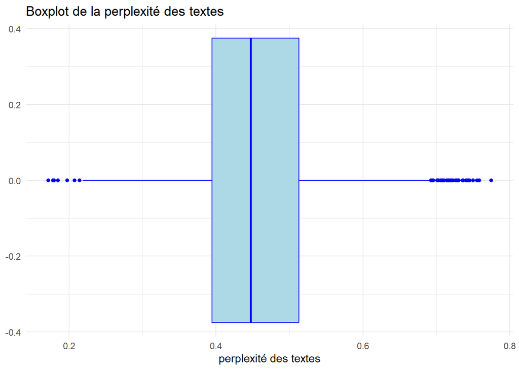

```r
ggplot(df_bayes, aes(x = perplexity_text)) +
  geom_boxplot(fill = "lightblue", color = "blue") +
  labs(title = "Boxplot de la perplexité des textes", x = "perplexité des textes") +
  theme_minimal()
```

Finalement, on remarque que dans cette colonne il n’y a pas de réel outliers posant réellement problème du coup on décide de ne supprimer aucun échantillon pour le moment.

Maintenant, la colonne variabilite_phrases:

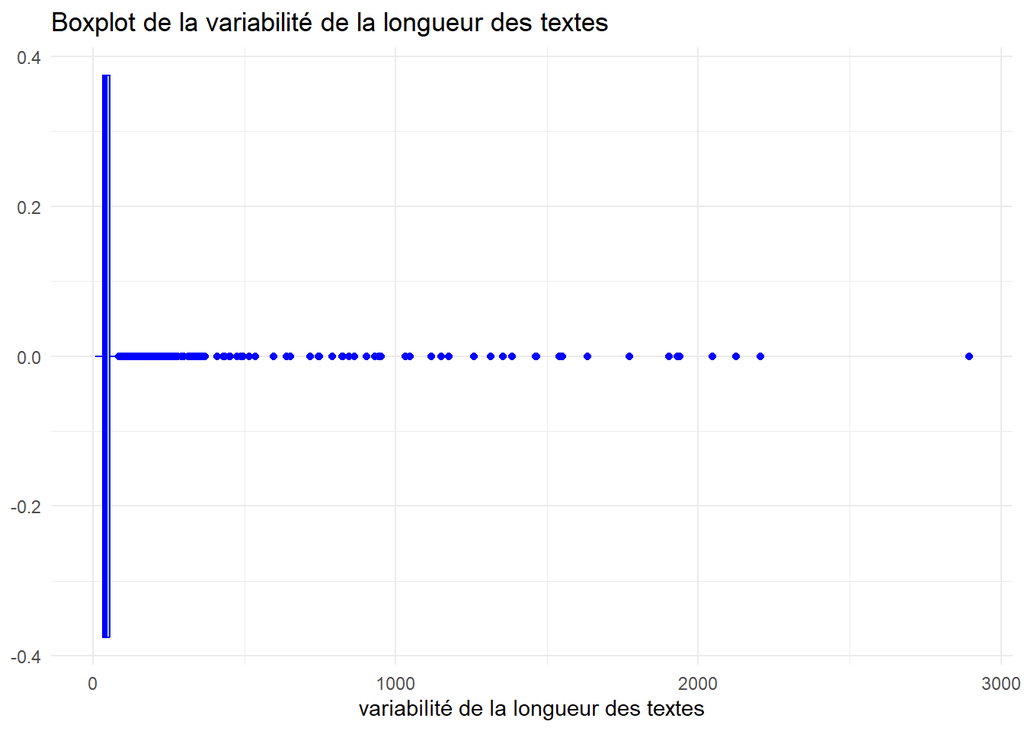

```r
ggplot(df_bayes, aes(x = variabilite_phrases)) +
  geom_boxplot(fill = "lightblue", color = "blue") +
  labs(title = "Boxplot de la variabilité de la longueur des textes", x = "variabilité de la longueur des textes") +
  theme_minimal()
```

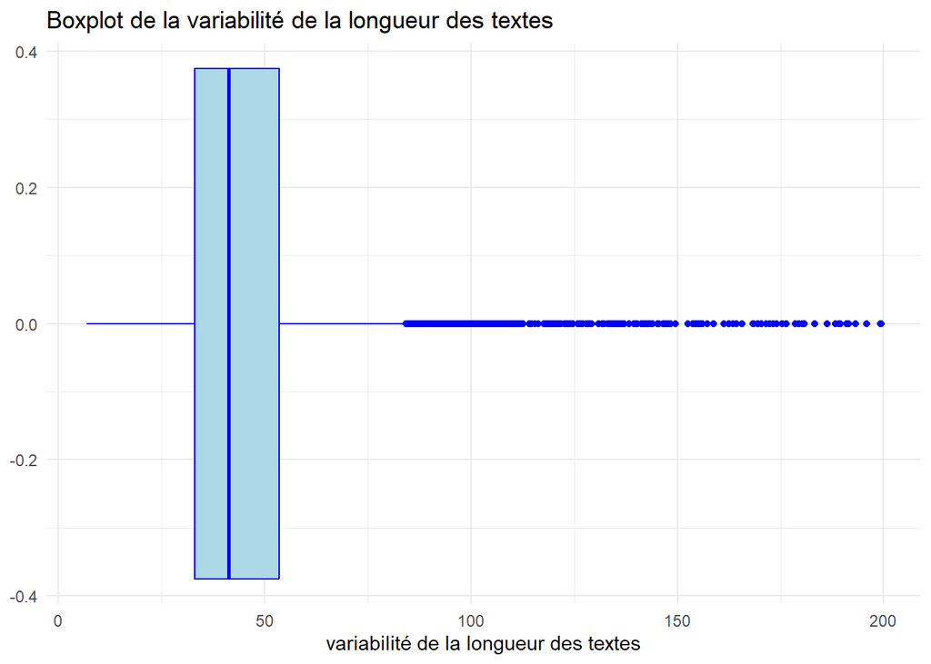

```r
df_bayes <- subset(df_bayes, variabilite_phrases <= 200)

ggplot(df_bayes, aes(x = variabilite_phrases)) +
  geom_boxplot(fill = "lightblue", color = "blue") +
  labs(title = "Boxplot de la variabilité de la longueur des textes", x = "variabilité de la longueur des textes") +
  theme_minimal()
```

Pour le coup, quand on regarde le premier boxplot, on voit bien qu’il y a plusieur outliers dans cette colonne. On décide donc de les supprimer. Ainsi, on retire toutes les valeurs au dessus de 200. Suite à ces suppressions, on peut voir que la distribution des valeurs de cette colonne est largement meilleur (deuxième boxplot) même s’il reste quel outliers mais il n’y a plus d’outliers qui sont réellement éloignées des autres valeurs donc on décide de ne plus plus supprimer d’échantillon.

Pour finir, la colonne score_lisibilite:

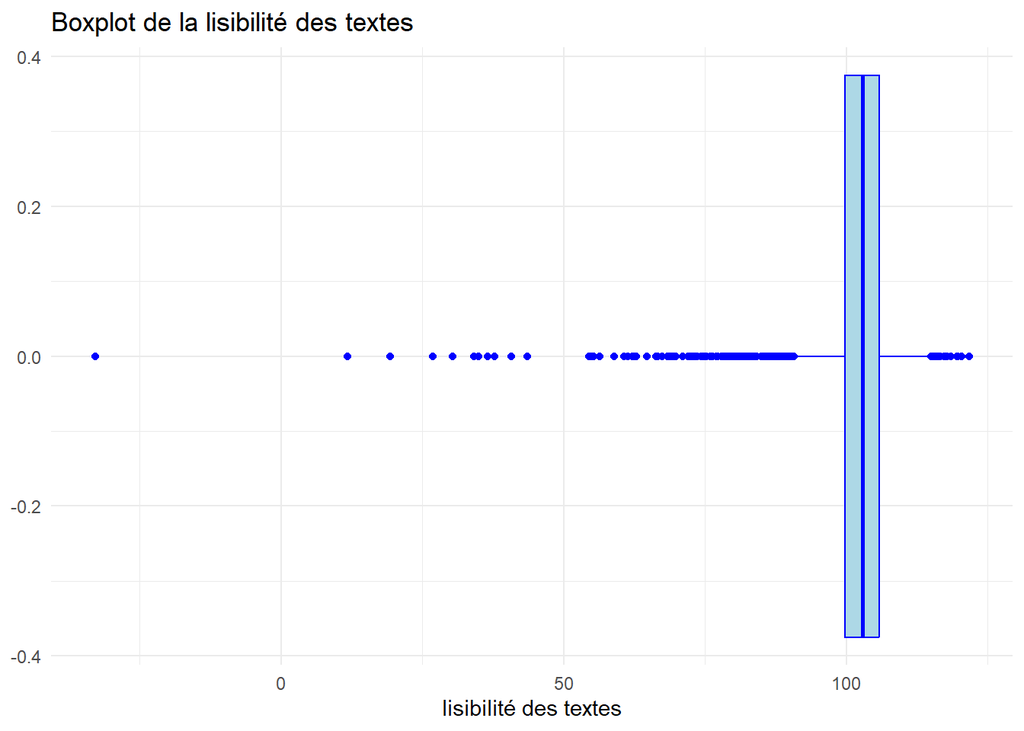

```r
ggplot(df_bayes, aes(x = score_lisibilite)) +
  geom_boxplot(fill = "lightblue", color = "blue") +
  labs(title = "Boxplot de la lisibilité des textes", x = "lisibilité des textes") +
  theme_minimal()
```

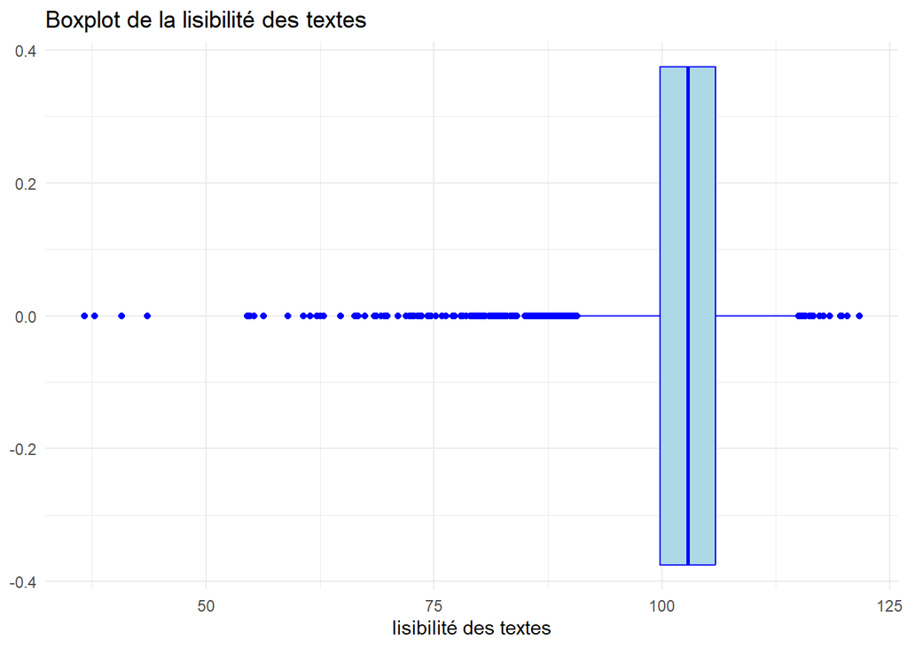

```r
df_bayes <- subset(df_bayes, score_lisibilite >= 35)

ggplot(df_bayes, aes(x = score_lisibilite)) +
  geom_boxplot(fill = "lightblue", color = "blue") +
  labs(title = "Boxplot de la lisibilité des textes", x = "lisibilité des textes") +
  theme_minimal()
```

Dans cette colonne aussi quand on regarde le premier boxplot, on voit bien qu’il y a plusieur outliers dans cette colonne. On décide donc de les supprimer. Ainsi, on retire toutes les valeurs inférieur à 35. Suite à ces suppressions, on peut voir que la distribution des valeurs de cette colonne est largement meilleur (deuxième boxplot) même s’il reste quel outliers mais il n’y a plus d’outliers qui sont réellement éloignées des autres valeurs donc on décide de ne plus plus supprimer d’échantillon.

On regarde les nouvelles dimensions de notre dataset:

```r
cat("Dimensions de df_bayes : ", dim(df_bayes), "\n")
```

```
## Dimensions de df_bayes :  5880 5
```

On a supprimé environ 100 échantillons avec cette stratégie et avons maintenant aux alentours de 5900 lignes.

#### 4.3 Modèle bayésien :

Pour cela, on va utiliser le package e1071 R pour entraîner un classifieur bayésien naïf.

Tout d’abord, on va diviser nos données en un ensemble d’apprentissage et un ensemble de test. On décide que notre dataset d’entrainement possédera 80% des données.

```r
#séparation des données en un dataset d'entrainement et de test
X <- as.matrix(subset(df_bayes, select = -c(label)))
y <- subset(df_bayes, select = label)

cat("Dimensions de X : ", dim(X), "\n")
```

```
## Dimensions de X :  5880 4
```

```r
n <- nrow(df_bayes)
index <- sample(1:n, 0.8 * n)

X_train <- X[index, ]
y_train <- y[index, ]
X_test <- X[-index, ]
y_test <- y[-index, ]


cat("Dimensions de X_train : ", dim(X_train), "\n")
```

```
## Dimensions de X_train :  4704 4
```

```r
cat("Dimensions de X_test : ", dim(X_test), "\n")
```

```
## Dimensions de X_test :  1176 4
```

```r
y_test %>%
  head() %>%
  kbl() %>%
  kable_styling(bootstrap_options = "striped", full_width = FALSE,
                position = "center")
```

| x |
| --- |
| human |
| human |
| human |
| human |
| human |
| human |

Ainsi, notre dataset d’entrainement sera composé d’environ 4700 échantillons tandis que celui de test sera composé d’environ 1180 échantillons.

On utilise le modèle naiveBayes de la librairie e1071 sur nos ensembles d’entrainement:

```r
#entrainement du modèle bayésien sur nos données d'entrainement
model <- naiveBayes(X_train, y_train)
print(model)
```

```
##
## Naive Bayes Classifier for Discrete Predictors
##
## Call:
## naiveBayes.default(x = X_train, y = y_train)
##
## A-priori probabilities:
## y_train
##    human       IA
## 0.485119 0.514881
##
## Conditional probabilities:
##        LD1
## y_train      [,1]      [,2]
##   human -4.454817 0.9714259
##   IA     4.459875 1.0043487
##
##        perplexity_text
## y_train      [,1]       [,2]
##   human 0.4395535 0.08264144
##   IA    0.4748113 0.09392449
##
##        variabilite_phrases
## y_train     [,1]     [,2]
##   human 56.09456 27.10164
##   IA    38.50907 12.44656
##
##        score_lisibilite
## y_train     [,1]     [,2]
##   human 101.0310 7.856733
##   IA    103.3042 4.332317
```

Il est temps de voir la fiabilité de notre modèle. Pour cela, on utilise notre dataset de test:

```r
#prédictions du modèle sur nos données de test
predictions <- predict(model, X_test)

predictions
```

```
##    [1] human human human human human human human human human human human human
##   [13] human human human human human human human human human human human human
##   [25] human human human human human human human human human human human human
##   [37] human human human human human human human human human human human human
##   [49] human human human human human human human human human human human human
##   [61] human human human human human human human human human human human human
##   [73] human human human human human human human human human human human human
##   [85] human human human human human human human human human human human human
##   [97] human human human human human human human human human human human human
##  [109] human human human human human human human human human human human human
##  [121] human human human human human human human human human human human human
##  [133] human human human human human human human IA    IA    IA    IA    IA
##  [145] IA    IA    IA    IA    IA    IA    IA    IA    IA    IA    IA    IA
##  [157] IA    IA    IA    IA    IA    IA    IA    IA    IA    IA    IA    IA
##  [169] IA    IA    IA    IA    IA    IA    IA    IA    IA    IA    IA    IA
```

[output cut: 84 more lines]

On voit que les prédictions de notre modèle forment des blocks. Il prédit de nombreuse fois humains à la suite et pareil pour IA. On verra lors de l’évaluation de notre modèle si c’est normal.

## 5. Évaluation du modèle :

Dans cette partie on va évaluer notre modèle à l’aide de différentes métrique (accuracy, matrice de confusion …). Pour calculer ces métriques, on utilise la fonction confusionMatrix de la librairie Caret.

On commence par l’accuracy:

```r
#métriques du modèle affichant la fiabilité de celui-ci
confusion_matrix <- confusionMatrix(predictions, y_test)

accuracy <- confusion_matrix$overall["Accuracy"]
mesure <- confusion_matrix$byClass

cat("Exactitude:", accuracy, "\n")
```

```
## Exactitude: 1
```

L’accuracy de notre modèle varie en 99.9% et 100% ce qui est parfait. Il fait très peu voire aucune erreur sur nos données de tests.

Pour mieux visualiser la performance de notre modèle, on va regarder d’autre métriques:

```r
mesure %>%
  kbl() %>%
  kable_styling(bootstrap_options = "striped", full_width = FALSE,
                position = "center")
```

|  | x |
| --- | --- |
| Sensitivity | 1.0000000 |
| Specificity | 1.0000000 |
| Pos Pred Value | 1.0000000 |
| Neg Pred Value | 1.0000000 |
| Precision | 1.0000000 |
| Recall | 1.0000000 |
| F1 | 1.0000000 |
| Prevalence | 0.5102041 |
| Detection Rate | 0.5102041 |
| Detection Prevalence | 0.5102041 |
| Balanced Accuracy | 1.0000000 |

Pour finir, on regarde la matrice de confusion:

```r
#matrice de confusion de notre modèle bayésien
matrice <- confusion_matrix$table

matrice %>%
  kbl() %>%
  kable_styling(bootstrap_options = "striped", full_width = FALSE,
                position = "center")
```

|  | human | IA |
| --- | --- | --- |
| human | 600 | 0 |
| IA | 0 | 576 |

On voit bien que notre modèle est très robuste. Après plusieurs compilations pour voir comment varie les résultats, le nombre d’erreurs est de maximum trois ce qui est infime.

Ces résultats indique que le modèle est capable de distinguer de manière précise et fiable les deux classes. Cela montre que notre modèle est très performant

## 6. Conclusion :

En conclusion de ce projet, les résultats montre un vrai succès dans la prédiction de l’origine des textes, qu’ils soient générés par une IA ou écrits par des humains.

Durant ce projet, on a calculé différentes caractéristiques de nos textes comme la TF-IDF ou la lisibilité, pour ensuite appliquer une réduction de dimensionnalité à l’aide de l’Analyse Discriminante Linéaire (LDA), passant ainsi de plus de 3000 colonnes à une seule.

Le modèle bayésien utilisé ensuite pour la prédiction a montré une très bonne performance  
avec une accuracy de plus de 99%, ce qui suggère une capacité très élevée à distinguer entre les textes générés par IA et ceux écrits par des humains. Ces résultats sont soutenus par les métriques comme la score F1 ou la spécificité.

Ainsi, a travers ce projet, on a réussi à atteindre notre objectif en fournissant un modèle de prédiction efficace et précis pour distinguer les textes d’origine humaine de ceux générés par IA.